# Informe HDT1

### 5.5 ¿Cuáles son las películas más viejas?

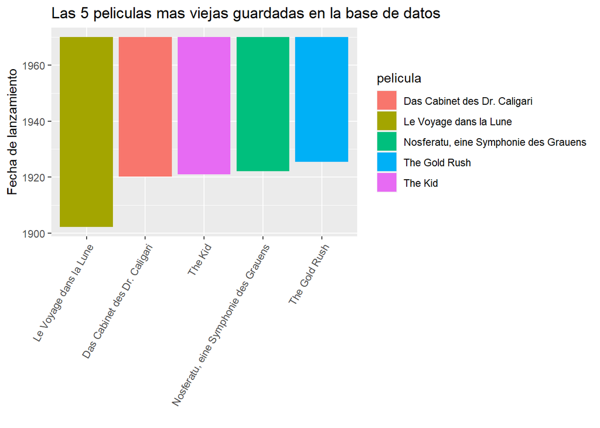

```r
preguntaEx5
```

Como se observa en la grafica anterior las peliculas mas viejas guardadas en el sistem son:  
1. **Le Voyage dans la Lune** lanzada el **1902-04-17**  
2. **Das Cabinet des Dr. Caligari** lanzada el **1920-02-27**  
3. **The Kid** lanzada el **1921-01-21**  
4. **Nosferatu, eine Symphonie des Grauens** lanzada el **1922-02-17**  
5. **The Gold Rush** lanzada el **1925-07-12**

### 5.6 Peliculas con mayores paises visitados para su rodaje

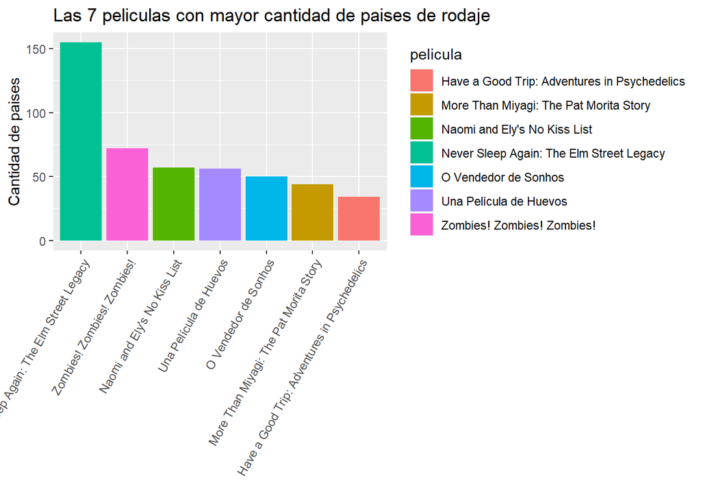

```r
preguntaEx6
```

Como se observa en la grafica anterior las peliculas con mayor cantidad de paises de rodaje son:  
1. **Never Sleep Again: The Elm Street Legacy** con una cantidad de **155** paises para llevarse a cabo  
2. **Zombies! Zombies! Zombies!** con una cantidad de **72** paises para llevarse a cabo  
3. **Naomi and Ely’s No Kiss List** con una cantidad de **57** paises para llevarse a cabo  
4. **Una Película de Huevos** con una cantidad de **56** paises para llevarse a cabo  
5. **O Vendedor de Sonhos** con una cantidad de **50** paises para llevarse a cabo  
6. **More Than Miyagi: The Pat Morita Story** con una cantidad de **44** paises para llevarse a cabo  
7. **Have a Good Trip: Adventures in Psychedelics** con una cantidad de **34** paises para llevarse a cabo